# Reticulate

Fellipe Gomes

21 de abril de 2018

# Instrução inicial* (Importante)

Para utilizar o Python e o Markdown de forma que seja possível renderizar o documento para obter o output, antes é nescessário conferir se as configurações de `PATH` do sistema não estão dando conflito.

A seguinte solução proposta [neste link do stackoverflow](https://stackoverflow.com/questions/41994485/error-could-not-find-or-load-the-qt-platform-plugin-windows-while-using-matplo) resolveu ou problema:

- Open Control Panel-> System Settings -> Advanced System Settings ->Environment Variables ->New. Set Variable Name: QT_PLUGIN_PATH , Variable Directory:

`C:\Users\Fellipe\Anaconda3` e `C:\Program Files\MiKTeX 2.9\miktex\bin\x64`

# O pacote reticulate

O pacote reticulate fornece um conjunto abrangente de ferramentas para interoperabilidade entre o Python e o R. O pacote inclui recursos para:

[figure not shown]

- Chamando Python de R de várias maneiras, incluindo R Markdown, sourcing de scripts Python, importando módulos Python e usando Python interativamente dentro de uma sessão R.
- Tradução entre objetos R e Python (por exemplo, entre quadros de dados R e Pandas, ou entre matrizes R e matrizes NumPy).
- Ligação flexível para diferentes versões do Python, incluindo ambientes virtuais e ambientes Conda.

O Reticulate incorpora uma sessão Python em sua sessão R, permitindo interoperabilidade perfeita e de alto desempenho. Se você é um desenvolvedor de R que usa Python para algum de seus trabalhos ou um membro da equipe de ciência de dados que usa os dois idiomas, o reticulate pode simplificar drasticamente seu fluxo de trabalho!

## Começando

#### Instalação

Instale o pacote reticulado do CRAN da seguinte maneira:

```r
install.packages("reticulate")
```

#### Versão em Python

Por padrão, o reticulate usa a versão do Python encontrada em seu PATH (por exemplo, `Sys.which("python")`).

#### Fornecendo dicas

Há duas maneiras de fornecer dicas sobre qual versão do Python deve ser usada:

1 - Configurando o valor da variável de ambiente `RETICULATE_PYTHON` para um binário do Python. Observe que, se você definir essa variável de ambiente, a versão especificada do Python sempre será usada (isto é, prescritiva, em vez de consultiva). Para definir o valor de `RETICULATE_PYTHON`, insira `Sys.setenv(RETICULATE_PYTHON = PATH)` no .Rprofile do seu projeto, onde `PATH` é seu binário Python preferido.

2 -Ao chamar uma destas funções:

| Descrição | da função |
| --- | --- |
| `use_python()` | Especifique o caminho de um binário específico do Python. |
| `use_virtualenv()` | Especifique o diretório que contém um virtualenv do Python. |
| `use_condaenv()` | Especifique o nome de um ambiente Conda. |

A função `use_python()` permite que você especifique uma versão alternativa, por exemplo:

```r
library(reticulate)
# use_python("C:/Users/gomes/Anaconda3")
use_virtualenv("~/myenv")
use_condaenv("myenv")
```

#### Pacotes Python

Você pode instalar qualquer pacote Python requerido usando ferramentas de shell padrão como `pip` e`conda`. Alternativamente, reticulate inclui um conjunto de funções para gerenciar e instalar pacotes dentro de virtualenvs e Ambientes Conda. Veja o artigo sobre [Instalando o Python Pacotes](https://rstudio.github.io/reticulate/articles/python_packages.html) para detalhes adicionais.

#### Chamando o Python

Existem várias maneiras de integrar o código Python ao seu R projetos:

1. Python no Markdown R - Um novo Python mecanismo de linguagem para R Markdown que suporta bidirecional comunicação entre R e Python (os fragmentos R podem acessar o Python objetos e vice-versa).
2. Importando módulos Python - O A função `import ()` permite importar qualquer módulo Python e chamar funciona diretamente de R.
3. Sourcing de scripts em Python - O A função `source_python()` permite que você crie um script Python mesma maneira que você iria `source ()` um script R (funções Python e objetos definidos dentro do script ficam diretamente disponíveis para o R sessão).
4. REPL do Python - A função `repl_python()` cria um console interativo do Python dentro de R. Objetos que você cria dentro Python estão disponíveis para sua sessão R (e vice-versa).

Cada uma dessas técnicas é explicada em mais detalhes abaixo.

## Python in R Markdown

O pacote ** reticulate ** inclui um mecanismo Python para [R Markdown](http://rmarkdown.rstudio.com) com os seguintes recursos:

1. Execute pedaços de Python em uma única sessão do Python incorporada em seu R session (shared variables / state entre pedaços de Python)
2. Impressão de saída em Python, incluindo saída gráfica de [matplotlib](https://matplotlib.org/).
3. Acesso a objetos criados dentro de blocos do Python usando o `py` objeto (por exemplo, `py $ x` acessaria uma variável`x` criada dentro Python de R).
4. Acesso a objetos criados dentro de R chunks do Python usando o `r` objeto (por exemplo, `r.x` acessaria a variável`x` criada dentro de R de Python)

A conversão interna para muitos tipos de objeto Python é fornecida, incluindo [NumPy](http://www.numpy.org/) matrizes e [Pandas](https://pandas.pydata.org/) quadros de dados. Do exemplo, você pode use Pandas para ler e manipular dados, em seguida, plotar facilmente os dados do Pandas frame usando [ggplot2](http://ggplot2.org/):

```python
# Chunk em Python
import pandas
iris = pandas.read_csv("iris.csv")
```

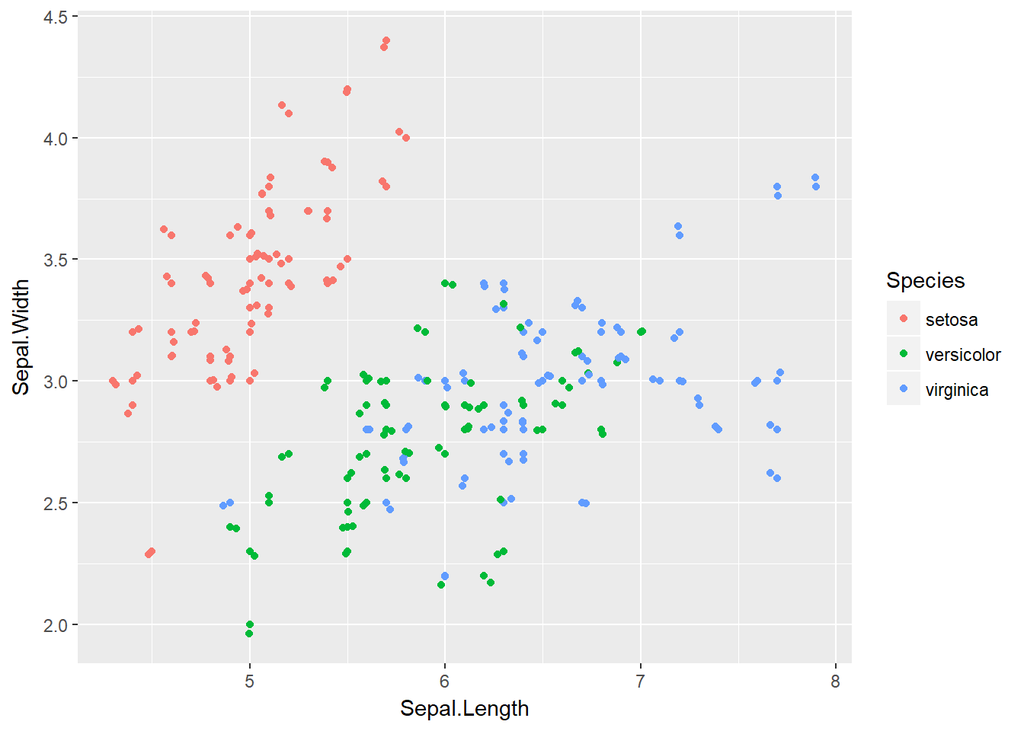

```r
# Chunk em R
library(ggplot2)
ggplot(py$iris, aes(Sepal.Length, Sepal.Width, col=Species))+
  geom_point()+
  geom_jitter()
```

Observe que o mecanismo Python reticulado é ativado por padrão dentro de R Markdown sempre que o reticulate estiver instalado.

Veja o [R Markdown Python Engine](https://rstudio.github.io/reticulate/articles/r_markdown.html) documentação para detalhes adicionais.

## Importando módulos Python

Você pode usar a função `import ()` para importar qualquer módulo Python e chamar a partir de R. Por exemplo, este código importa o módulo `os` do Python e chama a função `listdir ()`:

```r
library(reticulate)
os <- import("os")
os$listdir(".")
```

Funções e outros dados dentro de módulos e classes do Python podem ser acessado através do operador `$` (análogo ao modo como você interage com uma lista R, ambiente ou classe de referência).

Os módulos importados do Python suportam o preenchimento de código e a ajuda em linha:

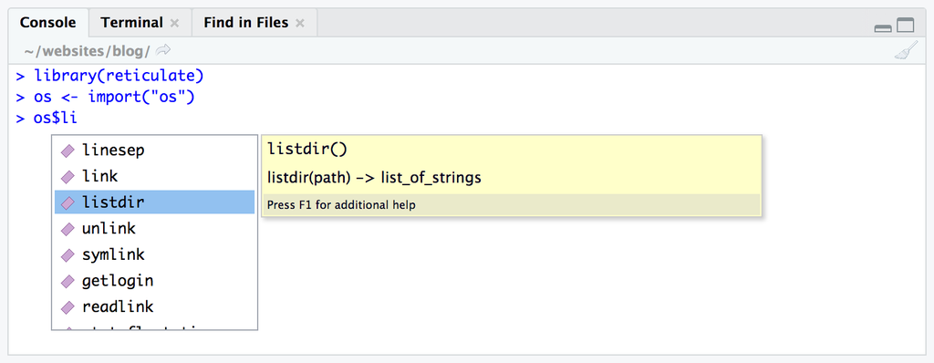

Veja [Chamando o Python de R](https://rstudio.github.io/reticulate/articles/calling_python.html) para detalhes adicionais sobre como interagir com objetos Python de dentro de R.

## Sourcing de scripts Python

Você pode criar qualquer script Python da mesma forma que você cria um script R usando a função `source_python()`. Por exemplo, se você tivesse o seguindo o script Python *iris.py* :

```python
# Codigo em Python
import pandas
def read_iris(file):
  iris = pandas.read_csv(file)
  return iris
```

Então você pode criar o script e chamar a função `read_iris()` como segue:

```r
# Codigo em R
source_python("iris.py")
iris <- read_iris("iris.csv")

ggplot(py$iris, aes(Sepal.Length, Sepal.Width, col=Species))+
  geom_point()+
  geom_jitter()
```

Veja a documentação `source_python()` para detalhes adicionais sobre código Python de sourcing.

## REPL de Python

Digite `exit` dentro do Python REPL para retornar ao prompt R.

Observe que o código Python também pode acessar objetos de dentro da sessão R usando o objeto `r` (por exemplo`r.flights`). Veja o `repl_python ()` documentação para detalhes adicionais sobre como usar o REPL incorporado em Python.

## Conversão entre R e Python

reticulate fornece os genéricos `r_to_py()` para converter objetos R em objetos Python e `py_to_r()` para converter objetos Python de volta em objetos R. Os autores de pacotes podem fornecer métodos para esses genéricos converterem objetos Python e R que não são manipulados por reticulate.

reticulate fornece operadores de conversão para alguns dos objetos Python mais usados, incluindo:

- Objetos Python incorporados (listas, dicionários, números, strings, tuplas)
- Matrizes NumPy,
- Objetos Pandas (Index, Series, DataFrame),
- Objetos de data e hora do Python.

Ao chamar o Python, os tipos de dados R são convertidos automaticamente para seus tipos equivalentes de Python. Quando os valores são retornados do Python para o R eles são convertidos de volta para os tipos R. Tipos são convertidos como segue:

| R | Python | Exemplos |
| --- | --- | --- |
| Vetor de elemento único | Escalar | `1`,`1L`, `TRUE`,`"foo"` |
| Vetor de vários elementos | List | `c (1.0, 2.0, 3.0)`, `c (1L, 2L, 3L)` |
| Lista de vários tipos | Tuple | `list (1L, TRUE," foo ")` |
| Lista nomeada | Dict | `list (a = 1L, b = 2.0)`, `dict (x = x_data)` |
| Matriz / Matriz | Nump | ndarray |
| Quadro de dados | Pandas DataFrame | `data.frame (x = c (1,2,3), y = c (" a "," b "," c "))` |
| Função | Função Python | `função (x) x + 1` |
| `NULL`, `TRUE`, `FALSE` | `None`, `True`, `False` | `NULL`,`TRUE`, `FALSE` |

Se um objeto Python de uma classe personalizada for retornado, então uma referência R para esse objeto é retornado. Você pode chamar métodos e acessar propriedades de o objeto como se fosse uma instância de uma classe de referência R.

## Por que reticular?

Da [Wikipedia](https://en.wikipedia.org/wiki/Reticulated_python) artigo sobre o python reticulado:

> O python reticulado é uma espécie de python encontrado no sudeste da Ásia. Eles são as cobras mais longas do mundo e os répteis mais longos … O específico nome, reticulatus, significa latim “net-like”, ou reticulado, e é uma referência ao padrão de cores complexo.

De [Merriam-Webster](https://www.merriam-webster.com/dictionary/reticulate) definição de reticulate:

> 1: assemelhando-se a uma rede ou rede; especialmente: ter veias, fibras ou linhas cruzando uma folha reticulada. 2: ser ou envolver evolução mudança dependente da recombinação genética envolvendo diversos populações de cruzamento.

O pacote permite que você * reticule * o código Python em R, criando um nova raça de projeto que une as duas linguagens.

# Aprendendo mais

Os seguintes artigos cobrem os vários aspectos do uso **reticulado**

## Chamando o Python

[Chamando o Python de R](https://rstudio.github.io/reticulate/articles/calling_python.html) Descreve as várias maneiras de acessar objetos Python de R, bem como funções disponíveis para interações e conversões mais avançadas comportamento.

#### Conversão de objetos

Por padrão, quando os objetos Python são retornados para R, eles são convertidos em seus tipos R equivalentes. No entanto, se você preferir tornar a conversão de Python para R explícita e lidar com objetos nativos do Python por padrão, poderá passar `convert = FALSE` para a função de importação. Neste caso, a conversão de Python para R será desativada para o módulo retornado da importação. Por exemplo:

```r
# import numpy e não especifica nenhuma conversão automática de Python para R
np <- import ("numpy", convert = FALSE)
```

```r
# faça algumas manipulações de array com o NumPy
a <- np$array(c(1:4))
soma <- a$cumsum()
```

```r
# converter para R explicitamente no final
py_to_r(soma)
```

```
## [1]  1  3  6 10
```

Como ilustrado acima, se você precisar acessar um objeto R no final de seus cálculos, poderá chamar a função py_to_r () explicitamente.

#### Conseguindo ajuda

Você pode imprimir documentação em qualquer objeto Python usando a função py_help (). Por exemplo:

```r
os <- import ("os")
py_help(os$chdir)
```

## R Markdown Python Engine

[R Markdown Python Engine](https://rstudio.github.io/reticulate/articles/r_markdown.html) - Fornece detalhes sobre o uso de fragmentos do Python no R Markdown documentos, incluindo como chamar o código Python a partir de pedaços R e vice-versa.

#### Chunks de Python

Os fragmentos de código Python funcionam exatamente como os fragmentos de código R: o código Python é executado e qualquer saída impressa ou gráfica (matplotlib) é incluída no documento.

Todas as partes do Python são executadas em uma única sessão do Python, portanto, têm acesso a todos os objetos criados em partes anteriores. Opções de partes como echo, include, etc. funcionam como esperado.

Veja um documento R Markdown que demonstra isso:

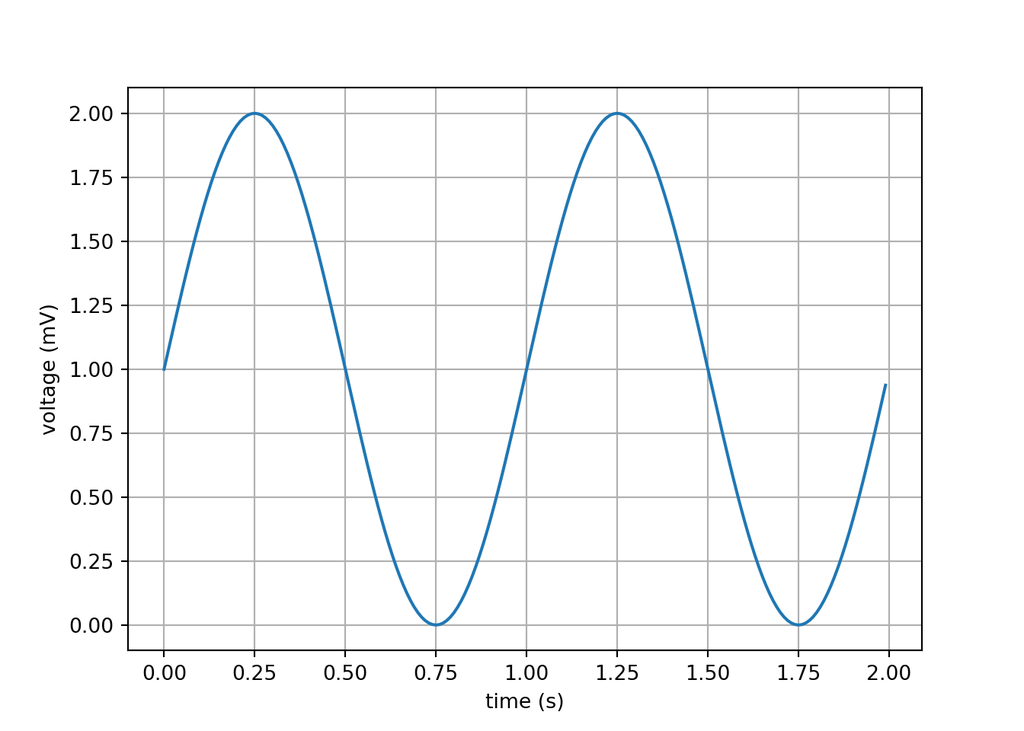

```python
# Chunk de python
import matplotlib.pyplot as plt
import numpy as np
t = np.arange(0.0, 2.0, 0.01)
s = 1 + np.sin(2*np.pi*t)
plt.plot(t,s)
plt.xlabel('time (s)')
plt.ylabel('voltage (mV)')
plt.grid(True)
plt.savefig('test.png')
plt.show()
```

- [Versão em Python Configuração](https://rstudio.github.io/reticulate/articles/versions.html)
- Descreve as facilidades para determinar qual versão do Python é usado por reticulate dentro de uma sessão R.
- [Instalando o Python Pacotes](https://rstudio.github.io/reticulate/articles/python_packages.html)
- Documentação sobre a instalação de pacotes Python do PyPI ou Conda, e gerenciar instalações de pacotes usando virtualenvs e Conda ambientes.
- [Usando reticulate em um R Pacote](https://rstudio.github.io/reticulate/articles/package.html)
- Diretrizes e melhores práticas para usar o reticulate em um R pacote.
- [Matrizes em R e Python](https://rstudio.github.io/reticulate/articles/arrays.html) - Discussão avançada das diferenças entre arrays em R e Python e as implicações para conversão e interoperabilidade.

# Fontes:

- https://github.com/rstudio/reticulate
- https://rstudio.github.io/reticulate/articles/r_markdown.html